# Assignment 1 - The tidyverse

Finn Krueger

September 27, 2022 | 11:41:13 | CEST

```r
library(tidyr)
library(dplyr)
library(legislatoR)
library(tibble)
library(lubridate)
library(stringi)
library(stringr)
library(ggplot2)
```

### Getting started with the Comparative Legislators Database

The Comparative Legislators Database (CLD) includes political, sociodemographic, career, online presence, public attention, and visual information for over 45,000 contemporary and historical politicians from ten countries (see the [corresponding article](https://www.cambridge.org/core/journals/british-journal-of-political-science/article/comparative-legislators-database/D28BB58A8B2C08C8593DB741F42C18B2) for more information). It can be accessed via `legislatoR` - an R package that is available on both [CRAN](https://cran.r-project.org/web/packages/legislatoR/index.html) and [GitHub](https://github.com/saschagobel/legislatoR).

Before you start with the following tasks, skim the tutorial to make yourself familiar with the database. You find it [here](https://cran.r-project.org/web/packages/legislatoR/vignettes/legislatoR.html).

For the following tasks, you will work with ONE of the legislatures. The legislature you’ll work with depends on your first name:

| Your first name starts with… | Legislature | Code |
| --- | --- | --- |
| A-C | Austrian Nationalrat | `aut` |
| D-F | Canadian House of Commons | `can` |
| G-I | Czech Poslanecka Snemovna | `cze` |
| J-L | Spanish Congreso de los Diputados | `esp` |
| M-O | French Assemblée | `fra` |
| P-R | German Bundestag | `deu` |
| S-U | Irish Dail | `irl` |
| V-X | UK House of Commons | `gbr` |
| Y-Z | US House of Representatives | `usa_house` |

The following tasks will be based on data from the `core` and `political` tables of the database.

### Task 1 - Descriptives [8 points in total]

1. What’s the overall share of male legislators in the entire dataset? [1 point]

```r
# with overall share I assume that you mean Canada ?
canada_house_core <- get_core(legislature = "can")

share_of_male <- canada_house_core %>%
  filter(sex == 'male')%>%
  nrow()%>%
  print()
```

```
[1] 4158
```

```r
share_of_male / canada_house_core %>%
  nrow()%>%
  print()
```

```
[1] 4515
```

```
[1] 0.9209302
```

2. How many (both in absolute and relative terms) legislators died in the same place they were born in? [1 point]

```r
Birth_equal_death<- canada_house_core%>%
  filter(birthplace == deathplace)%>%
  nrow()%>%
  print()
```

```
[1] 152
```

```r
Birth_equal_death / nrow(canada_house_core)%>%
  print()
```

```
[1] 4515
```

```
[1] 0.03366556
```

3. Create a new variable `age_at_death` that reports the age at which legislators died. Then, plot the distribution of that variable for the entire dataset. [2 points]

```r
summary(canada_house_core$birth)
```

```
                 Min.               1st Qu.                Median
"1787-08-13 00:00:00" "1859-06-11 00:00:00" "1902-02-11 00:00:00"
                 Mean               3rd Qu.                  Max.
"1899-08-10 05:42:51" "1940-10-03 00:00:00" "2000-01-01 00:00:00"
                 NA's
                 "88"
```

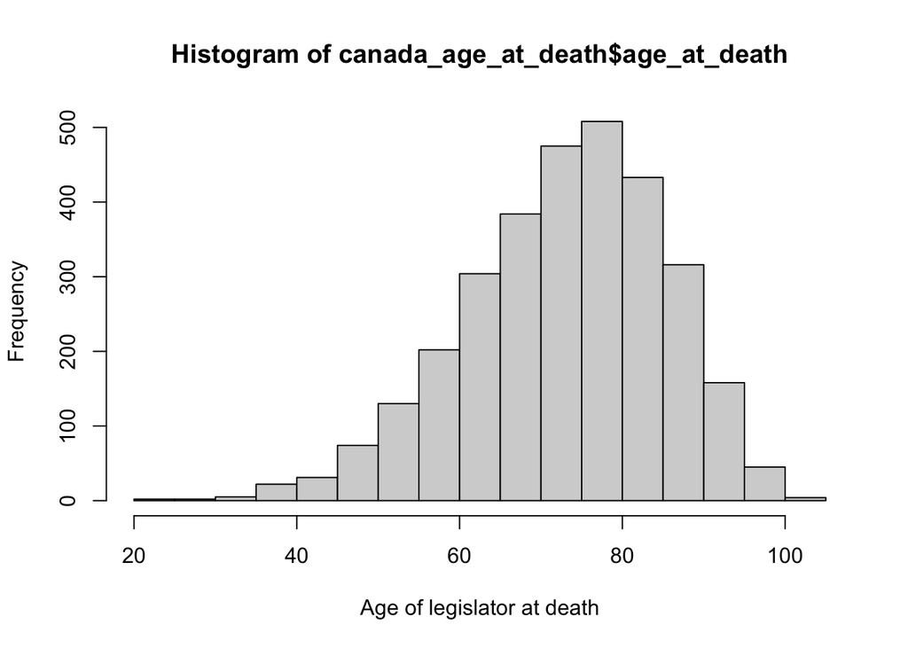

```r
canada_age_at_death <-
  canada_house_core %>%
  filter(!is.na(birth))%>%
  filter(!is.na(death))%>%
  mutate(age_at_death = lubridate::interval(birth, death) / years(1))


hist(canada_age_at_death$age_at_death, xlab = 'Age of legislator at death')
```

4. What is the most frequent birthday in your sample (e.g., “January 15”)? [2 points]

```r
birthdates <- format(canada_house_core, format="%m/%d")



Frequenca <- birthdates %>%
  filter(!is.na(birth)) %>%
  group_by(birth) %>%
  summarise(freq = (n()))%>%
  arrange(desc(freq))%>%
  print()
```

```
# A tibble: 366 × 2
   birth     freq
   <I<chr>> <int>
 1 01/01      257
 2 02/13       22
 3 11/10       22
 4 06/01       21
 5 04/10       20
 6 08/21       19
 7 02/14       18
 8 02/18       18
 9 04/30       18
10 05/26       18
# … with 356 more rows
```

5. Generate a table that provides the 5 legislators with the longest names (in terms of number of characters, ignoring whitespace). [2 points]

```r
legislator <- canada_house_core %>%
  mutate(longest_name =  str_replace_all(name, " ", ""))  %>%
  mutate(longest_name =  str_length(longest_name))

table_with_five_legistlators <- legislator %>%
  slice_max(longest_name, n = 5 )%>%
  select(name) %>%
  print()
```

```
                                                       name
1 Georges-Raoul-Léotale-Guichart-Humbert Saveuse de Beaujeu
2                   Joseph-Émile-Stanislas-Émmanuel D'Anjou
3                    Auguste-Charles-Philippe-Robert Landry
4                  Alexander Augustus Williamson Carscallen
5                     Honoré Julien Jean-Baptiste Chouinard
6                   Pamphile Réal Blaise Nugent Du Tremblay
7                    Joseph Étienne Letellier de Saint-Just
```

```r
table_with_five_legistlators <-  head(table_with_five_legistlators, n = 5)

print(table_with_five_legistlators)
```

```
                                                       name
1 Georges-Raoul-Léotale-Guichart-Humbert Saveuse de Beaujeu
2                   Joseph-Émile-Stanislas-Émmanuel D'Anjou
3                    Auguste-Charles-Philippe-Robert Landry
4                  Alexander Augustus Williamson Carscallen
5                     Honoré Julien Jean-Baptiste Chouinard
```

### Task 2 - Exploring trends in the data [8 points in total]

1. Using data from all sessions, provide a plot that shows the share of male legislators by session! [3 points]

```r
can_political <- get_political(legislature = "can")
glimpse(can_political)
```

```
Rows: 11,927
Columns: 15
$ pageid            <chr> "3608006", "1545901", "3589671", "2095757", "237612"…
$ session           <int> 1, 1, 1, 1, 1, 1, 1, 1, 1, 1, 1, 1, 1, 1, 1, 1, 1, 1…
$ party             <chr> "Liberal Party of Canada", "Liberal-Conservative Par…
$ constituency      <chr> "Annapolis", "Antigonish", "Cape Breton", "Colcheste…
$ constituency2     <chr> "Nova Scotia", "Nova Scotia", "Nova Scotia", "Nova S…
$ session_start     <date> 1867-09-20, 1867-09-20, 1867-09-20, 1867-09-20, 186…
$ session_end       <date> 1872-10-11, 1872-10-11, 1872-10-11, 1872-10-11, 187…
$ service           <int> 1848, 1848, 1848, 640, 252, 703, 1848, 1848, 1848, 1…
$ government        <lgl> FALSE, FALSE, FALSE, FALSE, FALSE, FALSE, TRUE, TRUE…
$ opposition        <lgl> TRUE, FALSE, FALSE, FALSE, FALSE, TRUE, FALSE, FALSE…
$ third             <lgl> FALSE, TRUE, TRUE, TRUE, TRUE, FALSE, FALSE, FALSE, …
$ unrecognized      <lgl> FALSE, FALSE, FALSE, FALSE, FALSE, FALSE, FALSE, FAL…
$ prime_minister    <lgl> FALSE, FALSE, FALSE, FALSE, FALSE, FALSE, FALSE, FAL…
$ opposition_leader <lgl> FALSE, FALSE, FALSE, FALSE, FALSE, FALSE, FALSE, FAL…
$ speaker           <lgl> FALSE, FALSE, FALSE, FALSE, FALSE, FALSE, FALSE, FAL…
```

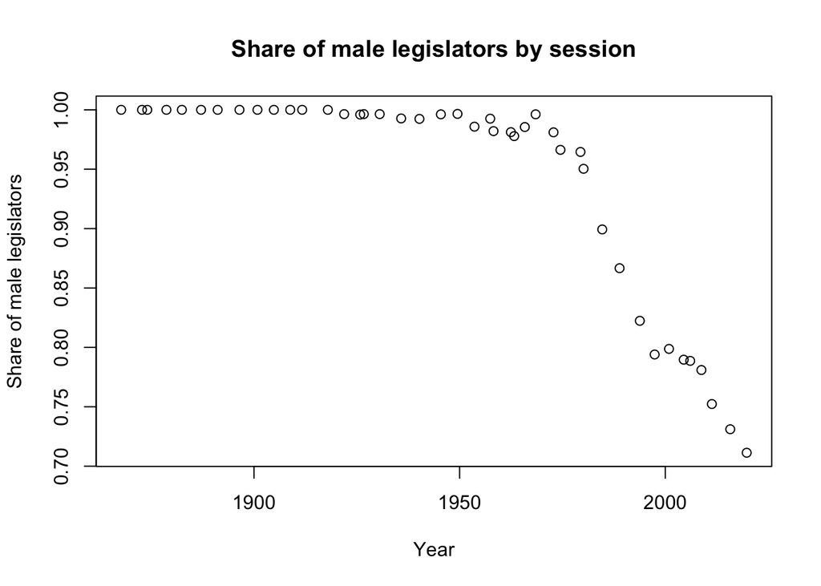

```r
canada_political_core <- canada_house_core %>% left_join(can_political, by = "pageid")


canada_session <-canada_political_core %>%
  group_by(session) %>%
  mutate(male = (sex == 'male'))  %>%
  summarize(male_ratio = mean(male, na.rm = TRUE),
            session_transformed = ymd(first(session_start)))


plot(canada_session$session_transformed,
     canada_session$male_ratio,
     ylab = "Share of male legislators",
     xlab = "Year",
     main = "Share of male legislators by session")
```

2. Explore another relation of variables in the dataset. Your analysis should (i) use data from both the `core` and the `political` table and (ii) feature data from several sessions. Also, offer a brief description and interpretation of your findings! [5 points]

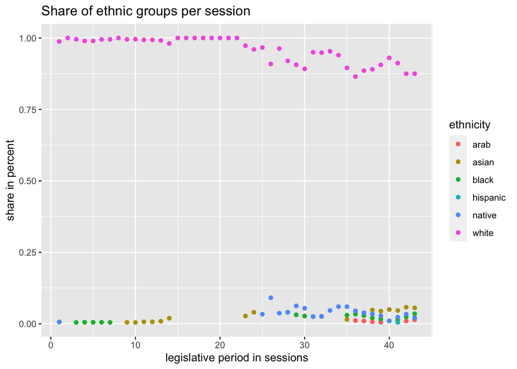

```r
# I use the already joined dataset canada_political_core <- canada_house_core %>% left_join(can_political, by = "pageid")

ethnicitiy_share <- canada_political_core%>%
  filter(!is.na(ethnicity))%>%
  group_by(session, ethnicity)%>%
    summarise(count = n())  %>%
    mutate(share_ethnicity = count / sum(count))

ggplot(ethnicitiy_share, aes(session, share_ethnicity, color = ethnicity)) +
  geom_point() +
  labs(title = "Share of ethnic groups per session",
       x = "legislative period in sessions",
       y = "share in percent")
```

In the X axis of the plot shows each legislative period in sessions, whereas on the Y axis displays the share of arab, asian, black, hispanic, native and white legislators for the given session.

Overall, the overall trend that we can observe is that the parliament is becoming more diverse. This trend holds for the overall increase in the share of legislators not being white, but also by the increasing diversity of different ethnicities of the legislators.